# Predicting Zip Code Relevancy in Developing Areas in and Around Austin, TX

#### By: Eric Lu

1. Data Gathering: Getting and Extracting GeoJson Data
   1. Steps to create GeoJson
   2. Orginal GeoJson Map
2. Selecting relevant zip codes
   1. Selecting relevant zip code boundary
      1. Test and Check best radius to use to find venues
      2. Finding Venues via Foursquare API
      3. Plot folium Choropleth based on Venue Count
      4. Selected Zip Codes
   2. Removing Developed Zip Codes
      1. Selecting selected zip codes from count data
      2. Removing Zip Codes from Count
      3. Removing Zip Codes from CVS
3. Gathering Zip Venue Data
   1. Function to calculate each search coordinate
   2. Calling API for Data
4. Clustering
   1. Clustering 1: K-Means Algorithm
      1. Calculate Unique Categories
      2. One hot encoding data
      3. Grouping Data to Zip code
      4. Top 10 types of Venues per Zip code
      5. Map of K-Means Cluster
   2. Clustering 2.1: Mean Shift Algorithm
      1. Simiplifying Categories
      2. One hot encoding categories
      3. Map of Mean Shift Cluster
   3. Clustering 2.2: Mean Shift Algorithm
      1. Map of Mean Shift Cluster
   4. Clustering 3.1: K-Means Algorithm
      1. Map of K-Means Cluster

```python
import pandas as pd
import numpy as np
import folium
import os
import requests
import json
import codecs
import seaborn as sns
import math
from sklearn.cluster import KMeans
from folium.features import DivIcon
import warnings
warnings.filterwarnings('ignore')
```

# Data Gathering: Getting and Extracting GeoJson Data

### Steps to create geojson from ZipCode Data

1. Get Zipcode data for entire state via https://github.com/OpenDataDE/State-zip-code-GeoJSON
2. Open zipcode geojson via QGIS and delete excess zip data
3. Convert shapefile to json https://mapshaper.org/
   1. simplify shapefile
      1. Menu: prevent shape removal
      2. Method: visvalingam / weighted area
   2. export geojson
   3. export csv for later ease of access
4. to convert json to geojson https://ogre.adc4gis.com/
5. convert prettify geojson https://jsonformatter.org/json-pretty-print

### Orginal GeoJson Map

```python
#https://stackoverflow.com/questions/13156395/python-load-json-file-with-utf-8-bom-header
#geojson_data = json.load(codecs.open('austin_zip_181.geojson', 'r', 'utf-8-sig'))
geojson_data = json.load(codecs.open(os.path.join('data', 'austin_zip_181.geojson'), 'r', 'utf-8-sig'))

m = folium.Map(location=[30.2672, -97.7431],tiles='OpenStreetMap', zoom_start=8)
folium.Choropleth(
    geo_data=geojson_data,
    key_on = 'feature.properties.ZCTA5CE10',
    fill_opacity=0.2,
    line_opacity=0.3,
    highlight=True
).add_to(m)
m
```

[interactive chart not shown]

```python
df_austin_zip_181 = pd.read_csv(os.path.join('data', 'austin_zip_181.csv'))#, index_col = 0)
df_austin_zip_181.head()
```

|  | STATEFP10 | ZCTA5CE10 | GEOID10 | CLASSFP10 | MTFCC10 | FUNCSTAT10 | ALAND10 | AWATER10 | INTPTLAT10 | INTPTLON10 | PARTFLG10 |
| --- | --- | --- | --- | --- | --- | --- | --- | --- | --- | --- | --- |
| 0 | 48 | 78650 | 4878650 | B5 | G6350 | S | 172543341 | 488366 | 30.303885 | -97.218899 | N |
| 1 | 48 | 76542 | 4876542 | B5 | G6350 | S | 208671526 | 2788181 | 31.009641 | -97.746417 | N |
| 2 | 48 | 76501 | 4876501 | B5 | G6350 | S | 302603143 | 2020926 | 31.075303 | -97.252433 | N |
| 3 | 48 | 76519 | 4876519 | B5 | G6350 | S | 132420522 | 557621 | 31.020832 | -97.120690 | N |
| 4 | 48 | 76569 | 4876569 | B5 | G6350 | S | 210970071 | 2438215 | 30.940183 | -97.227023 | N |

# Selecting relevant zip codes

## Selecting relevant zip code boundary

We want to find a relevant zip code boundary. We don't want zip codes that extend all the way to San Antonio but we still want enough area to make a meaningful prediction.

### Test and Check best radius to use to find venues

```python
geojson_data = json.load(codecs.open(os.path.join('data', 'austin_zip_181.geojson'), 'r', 'utf-8-sig'))

m = folium.Map(location=[30.2672, -97.7431],tiles='OpenStreetMap', zoom_start=8)
folium.Choropleth(
    geo_data=geojson_data,
    key_on = 'feature.properties.ZCTA5CE10',
    fill_opacity=0.2,
    highlight=True
).add_to(m)

folium.map.Marker(location=[30.2672, -97.7431], popup='Austin, TX').add_to(m)

for index, row in df_austin_zip_181.iterrows():
    folium.vector_layers.Circle(location=[row['INTPTLAT10'], row['INTPTLON10']], radius=2500, popup= folium.Popup(row['ZCTA5CE10'])).add_to(m)
m
```

[interactive chart not shown]

### Finding Venues via Foursquare API

```python
CLIENT_ID = 'MCHW4SBP13AEUUZPAB0NDIHD5PALKHUPJ0XFPNVMNU2M45C5' #'your-client-ID' # your Foursquare ID
CLIENT_SECRET = 'YTMSWOLIR03PGEP3ZKVV2OXFLIMCX1IDRQPAJGIT1ZW1HP3D' # your Foursquare Secret
VERSION = '20180604'
print('Your credentails:')
print('CLIENT_ID: ' + CLIENT_ID)
print('CLIENT_SECRET:' + CLIENT_SECRET)
```

```
Your credentails:
CLIENT_ID: MCHW4SBP13AEUUZPAB0NDIHD5PALKHUPJ0XFPNVMNU2M45C5
CLIENT_SECRET:YTMSWOLIR03PGEP3ZKVV2OXFLIMCX1IDRQPAJGIT1ZW1HP3D
```

```python
LIMIT = 100
def getNearbyVenues(names, latitudes, longitudes, radius=2500):

    venues_list=[]
    for name, lat, lng in zip(names, latitudes, longitudes):
        print(name, ', ', sep='', end='')

        # create the API request URL
        url = 'https://api.foursquare.com/v2/venues/explore?&client_id={}&client_secret={}&v={}&ll={},{}&radius={}&limit={}'.format(
            CLIENT_ID,
            CLIENT_SECRET,
            VERSION,
            lat,
            lng,
            radius,
            LIMIT)

        # make the GET request
        results = requests.get(url).json()["response"]['groups'][0]['items']

        # return only relevant information for each nearby venue
        venues_list.append([(
            name,
            lat,
            lng,
            v['venue']['name'],
            v['venue']['location']['lat'],
            v['venue']['location']['lng'],
            v['venue']['categories'][0]['name']) for v in results])

    nearby_venues = pd.DataFrame([item for venue_list in venues_list for item in venue_list])
    nearby_venues.columns = ['ZCTA5CE10',
                  'INTPTLAT10',
                  'INTPTLON10',
                  'Venue',
                  'Venue Latitude',
                  'Venue Longitude',
                  'Venue Category']
    print('done')
    return(nearby_venues)
```

```python
df_venues = getNearbyVenues(names=df_austin_zip_181['ZCTA5CE10'],
                                   latitudes=df_austin_zip_181['INTPTLAT10'],
                                   longitudes=df_austin_zip_181['INTPTLON10'])
print(df_venues.shape)
```

```
78650, 76542, 76501, 76519, 76569, 76508, 78669, 76567, 78656, 78655, 77475, 78947, 78728, 78739, 78633, 76530, 78957, 78659, 78621, 76541, 76543, 76559, 76502, 78256, 78636, 78644, 78666, 78661, 78130, 78132, 76656, 78675, 76518, 76523, 78759, 78703, 78735, 78725, 78721, 78738, 78641, 78626, 76537,…
(4247, 7)
```

#### Count venues in each Zip

```python
df_counts = df_venues['ZCTA5CE10'].value_counts().rename_axis('ZCTA5CE10').reset_index(name='Count')
df_counts['ZCTA5CE10'] = df_counts['ZCTA5CE10'].astype(str)
df_counts.head()
```

|  | ZCTA5CE10 | Count |
| --- | --- | --- |
| 0 | 78704 | 100 |
| 1 | 78705 | 100 |
| 2 | 78703 | 100 |
| 3 | 78723 | 100 |
| 4 | 78722 | 100 |

### Plot folium Choropleth based on Venue Count

Selected the general relevant area between "major" towns/areas around Austin. Since we want to find areas around Austin, we should not go past other "major" small towns/areas: they act as our boundary.

```python
geojson_data = json.load(codecs.open(os.path.join('data', 'austin_zip_181.geojson'), 'r', 'utf-8-sig'))

m = folium.Map(location=[30.2672, -97.7431],tiles='OpenStreetMap', zoom_start=8)
folium.Choropleth(
    geo_data=geojson_data,
    data=df_counts,
    columns=['ZCTA5CE10', 'Count'],
    key_on = 'feature.properties.ZCTA5CE10',#'feature.properties.ZCTA5CE10',
    fill_color='YlOrRd',
    fill_opacity=0.7,
    line_opacity=0.2,
    legend_name='Number of Venues within Radius',
    bins=5,
    highlight=True,
    reset=True
).add_to(m)

folium.vector_layers.Polygon(locations= [[29.8833,-97.9414], # San Marcos
                                         [29.8849,-97.67],   # Lockhart
                                         [30.1105,-97.3153], # Bastrop
                                         [30.5708,-97.4094], # Taylor
                                         [30.6333,-97.678],  # Georgetown
                                         [30.5788,-97.8531], # Leander
                                         [30.4602,-97.9883], # Lago Vista
                                         [30.1902,-98.0867]],# Dripping Springs
                                         popup=None).add_to(m)
m
```

[interactive chart not shown]

### Selected Zip Codes

```python
geojson_data = json.load(codecs.open(os.path.join('data', 'austin_zip_78.geojson'), 'r', 'utf-8-sig'))

m = folium.Map(location=[30.2672, -97.7431],tiles='OpenStreetMap', zoom_start=9)
folium.Choropleth(
    geo_data=geojson_data,
    key_on = 'feature.properties.ZCTA5CE10',
    fill_opacity=0.2,
    line_opacity=0.3,
    highlight=True
).add_to(m)

folium.vector_layers.Polygon(locations= [[29.8833,-97.9414], # San Marcos
                                         [29.8849,-97.67],   # Lockhart
                                         [30.1105,-97.3153], # Bastrop
                                         [30.5708,-97.4094], # Taylor
                                         [30.6333,-97.678],  # Georgetown
                                         [30.5788,-97.8531], # Leander
                                         [30.4602,-97.9883], # Lago Vista
                                         [30.1902,-98.0867]],# Dripping Springs
                                         popup=None).add_to(m)

m
```

[interactive chart not shown]

```python
df_austin_zip_78 = pd.read_csv(os.path.join('data', 'austin_zip_78.csv'))
df_austin_zip_78['ZCTA5CE10'] = df_austin_zip_78['ZCTA5CE10'].astype(str)
df_austin_zip_78.head()
#df_austin_zip_78[df_austin_zip_78['ZCTA5CE10'] == '76530']
```

|  | STATEFP10 | ZCTA5CE10 | GEOID10 | CLASSFP10 | MTFCC10 | FUNCSTAT10 | ALAND10 | AWATER10 | INTPTLAT10 | INTPTLON10 | PARTFLG10 |
| --- | --- | --- | --- | --- | --- | --- | --- | --- | --- | --- | --- |
| 0 | 48 | 78669 | 4878669 | B5 | G6350 | S | 361644669 | 23918120 | 30.430044 | -98.112655 | N |
| 1 | 48 | 78656 | 4878656 | B5 | G6350 | S | 55560781 | 304458 | 29.904759 | -97.807296 | N |
| 2 | 48 | 78655 | 4878655 | B5 | G6350 | S | 92420333 | 564687 | 29.816002 | -97.835042 | N |
| 3 | 48 | 78728 | 4878728 | B5 | G6350 | S | 21002465 | 47256 | 30.452674 | -97.689368 | N |
| 4 | 48 | 78739 | 4878739 | B5 | G6350 | S | 29613883 | 0 | 30.178419 | -97.888662 | N |

## Removing Developed Zip Codes

We want to remove all the zip codes that are already developed and irrelevant to our prediction.

### Selecting selected zip codes from count data

Selecting only the selected zip codes from df_counts (this is so we can do further analysis on which zip codes to remove)

```python
df_counts_selected = df_counts[df_counts['ZCTA5CE10'].isin(df_austin_zip_78['ZCTA5CE10'])].reset_index(drop=True)
df_counts_selected.shape
```

```
(76, 2)
```

Boxplot of the selected

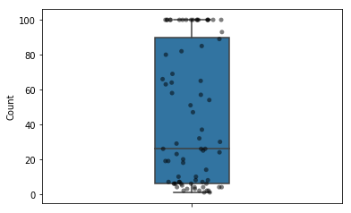

```python
bplot = sns.boxplot(y='Count',
                    data=df_counts_selected,
                    width=0.25)
bplot=sns.stripplot(y='Count',
                   data=df_counts_selected,
                   jitter=True,
                   marker='o',
                   alpha=0.5,
                   color='black')
```

### Removing Zip Codes from Count

We are considering any zip with a count above 80 as developed so we are removing them from our zip code dataset

```python
#df_counts_selected_removed = df_counts_selected[df_counts_selected['Count'] < df_counts_selected['Count'].quantile(.75)]
df_counts_selected_removed = df_counts_selected[df_counts_selected['Count'] < 80]
df_counts_removed = df_counts_selected[df_counts_selected['Count'] >= 80]
df_counts_selected_removed.shape
```

```
(53, 2)
```

```python
#geojson_data = json.load(codecs.open('austin_zip_78.geojson', 'r', 'utf-8-sig'))
geojson_data = json.load(codecs.open(os.path.join('data', 'austin_zip_78.geojson'), 'r', 'utf-8-sig'))

m = folium.Map(location=[30.2672, -97.7431],tiles='OpenStreetMap', zoom_start=9)
folium.Choropleth(
    geo_data=geojson_data,
    data=df_counts_selected_removed,
    columns=['ZCTA5CE10', 'Count'],
    key_on = 'feature.properties.ZCTA5CE10',#'feature.properties.ZCTA5CE10',
    fill_color='YlOrRd',
    fill_opacity=0.7,
    line_opacity=0.2,
    legend_name='Number of Venues within Radius',
    bins=[1,20,40,60,80,100],#5,
    highlight=True,
    reset=True
).add_to(m)

m
```

[interactive chart not shown]

### Removing Zip Codes from CVS

```python
df_zip_data = df_austin_zip_78[~df_austin_zip_78['ZCTA5CE10'].isin(df_counts_removed['ZCTA5CE10'])].reset_index(drop=True)
df_zip_data.shape
```

```
(54, 11)
```

# Gathering Zip Venue Data

```python
geojson_data = json.load(codecs.open(os.path.join('data', 'austin_zip_78.geojson'), 'r', 'utf-8-sig'))
df_zip_data.head()
```

|  | STATEFP10 | ZCTA5CE10 | GEOID10 | CLASSFP10 | MTFCC10 | FUNCSTAT10 | ALAND10 | AWATER10 | INTPTLAT10 | INTPTLON10 | PARTFLG10 |
| --- | --- | --- | --- | --- | --- | --- | --- | --- | --- | --- | --- |
| 0 | 48 | 78669 | 4878669 | B5 | G6350 | S | 361644669 | 23918120 | 30.430044 | -98.112655 | N |
| 1 | 48 | 78656 | 4878656 | B5 | G6350 | S | 55560781 | 304458 | 29.904759 | -97.807296 | N |
| 2 | 48 | 78655 | 4878655 | B5 | G6350 | S | 92420333 | 564687 | 29.816002 | -97.835042 | N |
| 3 | 48 | 78728 | 4878728 | B5 | G6350 | S | 21002465 | 47256 | 30.452674 | -97.689368 | N |
| 4 | 48 | 78739 | 4878739 | B5 | G6350 | S | 29613883 | 0 | 30.178419 | -97.888662 | N |

## Function to calculate each search coordinate

We want to gather a lot of data on each zip code area but the Foursquare API limits our results per search. To bypass this constraint, I have decided to make the search radius smaller but search more times around the original coordinate.

Foursquare API uses a radius parameter (in meters) to create a circle search area. To combind searches I will have to combind these "circle" area searches into a larger area.

[figure not shown]

Calculation used to calculate new coordinates based on distance changes in meters.

[figure not shown]

Calculation used to find the total/effective area that is being searched by the API: it comes out to be about 41 km squared or about 16 miles squared.

[figure not shown]

```python
def calc_surrounding_coords (orig_latitude, orig_longitude, radius):
    coord_list = []
    #orig_latitude = 30.4014
    #orig_longitude = -97.7525
    coord_list.append([orig_latitude, orig_longitude])

    #radius = 1000
    dy = radius
    dx = radius
    r_earth = 6371008.8

    #https://stackoverflow.com/questions/7477003/calculating-new-longitude-latitude-from-old-n-meters
    new_latitude  = orig_latitude  + (dy / r_earth) * (180 / math.pi)
    new_longitude = orig_longitude + (dx / r_earth) * (180 / math.pi) / math.cos(orig_latitude * math.pi/180)
    coord_list.append([new_latitude, new_longitude])

    new_latitude  = orig_latitude  + (dy / r_earth) * (180 / math.pi)
    new_longitude = orig_longitude - (dx / r_earth) * (180 / math.pi) / math.cos(orig_latitude * math.pi/180)
    coord_list.append([new_latitude, new_longitude])

    new_latitude  = orig_latitude  - (dy / r_earth) * (180 / math.pi)
    new_longitude = orig_longitude + (dx / r_earth) * (180 / math.pi) / math.cos(orig_latitude * math.pi/180)
    coord_list.append([new_latitude, new_longitude])

    new_latitude  = orig_latitude  - (dy / r_earth) * (180 / math.pi)
    new_longitude = orig_longitude - (dx / r_earth) * (180 / math.pi) / math.cos(orig_latitude * math.pi/180)
    coord_list.append([new_latitude, new_longitude])

    new_latitude  = orig_latitude
    new_longitude = orig_longitude + (2*dx / r_earth) * (180 / math.pi) / math.cos(orig_latitude * math.pi/180)
    coord_list.append([new_latitude, new_longitude])

    new_latitude  = orig_latitude
    new_longitude = orig_longitude - (2*dx / r_earth) * (180 / math.pi) / math.cos(orig_latitude * math.pi/180)
    coord_list.append([new_latitude, new_longitude])

    new_latitude  = orig_latitude  + (2*dy / r_earth) * (180 / math.pi)
    new_longitude = orig_longitude
    coord_list.append([new_latitude, new_longitude])

    new_latitude  = orig_latitude  - (2*dy / r_earth) * (180 / math.pi)
    new_longitude = orig_longitude
    coord_list.append([new_latitude, new_longitude])

    return coord_list
```

## Calling API for Data

```python
LIMIT = 100
def getNearbyVenues(names, latitudes, longitudes, radius=1000):

    venues_list=[]
    for name, lat, lng in zip(names, latitudes, longitudes):
        print(name, ', ', sep='', end='')

        coord_list = calc_surrounding_coords (lat, lng, radius)
        for coords in coord_list:
            # create the API request URL
            url = 'https://api.foursquare.com/v2/venues/explore?&client_id={}&client_secret={}&v={}&ll={},{}&radius={}&limit={}'.format(
                CLIENT_ID,
                CLIENT_SECRET,
                VERSION,
                coords[0],
                coords[1],
                radius,
                LIMIT)

            # make the GET request
            results = requests.get(url).json()["response"]['groups'][0]['items']

            # return only relevant information for each nearby venue
            venues_list.append([(
                name,
                lat,
                lng,
                v['venue']['name'],
                v['venue']['location']['lat'],
                v['venue']['location']['lng'],
                v['venue']['categories'][0]['name']) for v in results])

    nearby_venues = pd.DataFrame([item for venue_list in venues_list for item in venue_list])
    nearby_venues.columns = ['ZCTA5CE10',
                  'INTPTLAT10',
                  'INTPTLON10',
                  'Venue',
                  'Venue Latitude',
                  'Venue Longitude',
                  'Venue Category']
    print('done')
    return(nearby_venues)
```

```python
df_venues = getNearbyVenues(names=df_zip_data['ZCTA5CE10'],
                                   latitudes=df_zip_data['INTPTLAT10'],
                                   longitudes=df_zip_data['INTPTLON10'])
df_venues = df_venues.drop_duplicates()
print(df_venues.shape)
```

```
78669, 78656, 78655, 78728, 78739, 76530, 78621, 78644, 78666, 78735, 78725, 78721, 78641, 78626, 78622, 78619, 78744, 78645, 78660, 78616, 78640, 78652, 78750, 78732, 78736, 76574, 78620, 78737, 78742, 78734, 78612, 78754, 78733, 78719, 78726, 78730, 78634, 78717, 78602, 78617, 78953, 78662, 78676,…
(2113, 7)
```

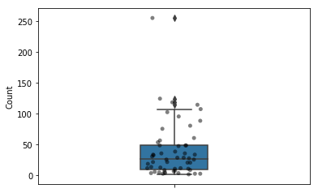

```python
df_counts = df_venues['ZCTA5CE10'].value_counts().rename_axis('ZCTA5CE10').reset_index(name='Count')
df_counts['ZCTA5CE10'] = df_counts['ZCTA5CE10'].astype(str)

bplot = sns.boxplot(y='Count',
                    data=df_counts,
                    width=0.25)
bplot=sns.stripplot(y='Count',
                   data=df_counts,
                   jitter=True,
                   marker='o',
                   alpha=0.5,
                   color='black')
```

# Clustering

## Clustering 1: K-Means Algorithm

### Calculate Unique Categories

```python
print('There are {} uniques categories.'.format(len(df_venues['Venue Category'].unique())))
```

```
There are 291 uniques categories.
```

### One hot encoding data

```python
# one hot encoding
df_onehot = pd.get_dummies(df_venues[['Venue Category']], prefix="", prefix_sep="")

# add neighborhood column back to dataframe
df_onehot['ZCTA5CE10'] = df_venues['ZCTA5CE10']

# move neighborhood column to the first column
fixed_columns = [df_onehot.columns[-1]] + list(df_onehot.columns[:-1])
df_onehot = df_onehot[fixed_columns]

df_onehot.head(2)
```

|  | ZCTA5CE10 | ATM | Advertising Agency | Airport | Airport Service | Airport Terminal | American Restaurant | Arcade | Art Gallery | Arts & Crafts Store | ... | Weight Loss Center | Well | Wine Bar | Wine Shop | Winery | Wings Joint | Women's Store | Yoga Studio | Zoo | Zoo Exhibit |
| --- | --- | --- | --- | --- | --- | --- | --- | --- | --- | --- | --- | --- | --- | --- | --- | --- | --- | --- | --- | --- | --- |
| 0 | 78669 | 0 | 0 | 0 | 0 | 0 | 0 | 0 | 0 | 0 | ... | 0 | 0 | 0 | 0 | 0 | 0 | 0 | 0 | 0 | 0 |
| 1 | 78669 | 0 | 0 | 0 | 0 | 0 | 0 | 0 | 0 | 0 | ... | 0 | 0 | 0 | 0 | 0 | 0 | 0 | 0 | 0 | 0 |

2 rows × 292 columns

### Grouping Data to Zip code

```python
df_grouped = df_onehot.groupby('ZCTA5CE10').mean().reset_index()
df_grouped.head(2)
```

|  | ZCTA5CE10 | ATM | Advertising Agency | Airport | Airport Service | Airport Terminal | American Restaurant | Arcade | Art Gallery | Arts & Crafts Store | ... | Weight Loss Center | Well | Wine Bar | Wine Shop | Winery | Wings Joint | Women's Store | Yoga Studio | Zoo | Zoo Exhibit |
| --- | --- | --- | --- | --- | --- | --- | --- | --- | --- | --- | --- | --- | --- | --- | --- | --- | --- | --- | --- | --- | --- |
| 0 | 76530 | 0.0 | 0.0 | 0.0 | 0.0 | 0.0 | 0.000000 | 0.0 | 0.0 | 0.0 | ... | 0.0 | 0.0 | 0.0 | 0.0 | 0.0 | 0.0 | 0.0 | 0.0 | 0.0 | 0.0 |
| 1 | 76574 | 0.0 | 0.0 | 0.0 | 0.0 | 0.0 | 0.057143 | 0.0 | 0.0 | 0.0 | ... | 0.0 | 0.0 | 0.0 | 0.0 | 0.0 | 0.0 | 0.0 | 0.0 | 0.0 | 0.0 |

2 rows × 292 columns

### Top 10 types of Venues per Zip code

```python
def return_most_common_venues(row, num_top_venues):
    row_categories = row.iloc[1:]
    row_categories_sorted = row_categories.sort_values(ascending=False)

    return row_categories_sorted.index.values[0:num_top_venues]

num_top_venues = 10

indicators = ['st', 'nd', 'rd']

# create columns according to number of top venues
columns = ['ZCTA5CE10']
for ind in np.arange(num_top_venues):
    try:
        columns.append('{}{} Most Common Venue'.format(ind+1, indicators[ind]))
    except:
        columns.append('{}th Most Common Venue'.format(ind+1))

# create a new dataframe
df_venues_sorted = pd.DataFrame(columns=columns)
df_venues_sorted['ZCTA5CE10'] = df_grouped['ZCTA5CE10']

for ind in np.arange(df_zip_data.shape[0]):
    df_venues_sorted.iloc[ind, 1:] = return_most_common_venues(df_grouped.iloc[ind, :], num_top_venues)

df_venues_sorted.head(2)
```

|  | ZCTA5CE10 | 1st Most Common Venue | 2nd Most Common Venue | 3rd Most Common Venue | 4th Most Common Venue | 5th Most Common Venue | 6th Most Common Venue | 7th Most Common Venue | 8th Most Common Venue | 9th Most Common Venue | 10th Most Common Venue |
| --- | --- | --- | --- | --- | --- | --- | --- | --- | --- | --- | --- |
| 0 | 76530 | Steakhouse | Gas Station | Bar | Forest | Football Stadium | Food Truck | Frame Store | Food Court | Food & Drink Shop | French Restaurant |
| 1 | 76574 | Construction & Landscaping | Fast Food Restaurant | Pharmacy | Seafood Restaurant | Discount Store | Mexican Restaurant | American Restaurant | Park | Baseball Field | Locksmith |

#### Training via K-means into 5 clusters

```python
# set number of clusters
kclusters = 5

df_grouped_clustering = df_grouped.drop('ZCTA5CE10', 1)

# run k-means clustering
kmeans = KMeans(n_clusters=kclusters, random_state=0).fit(df_grouped_clustering)

# check cluster labels generated for each row in the dataframe
kmeans.labels_[0:10]
```

```
array([3, 3, 3, 3, 0, 4, 3, 3, 3, 3], dtype=int32)
```

```python
# add clustering labels
df_venues_sorted.insert(0, 'Cluster Labels', kmeans.labels_)

df_merged = df_zip_data

# merge toronto_grouped with toronto_data to add latitude/longitude for each neighborhood
df_merged = df_merged.join(df_venues_sorted.set_index('ZCTA5CE10'), on='ZCTA5CE10')

df_merged = df_merged.drop(['STATEFP10',
                            'GEOID10',
                            'CLASSFP10',
                            'MTFCC10',
                            'FUNCSTAT10',
                            'ALAND10',
                            'AWATER10',
                            'PARTFLG10'], axis=1)
df_merged.head(2) # check the last columns!
```

|  | ZCTA5CE10 | INTPTLAT10 | INTPTLON10 | Cluster Labels | 1st Most Common Venue | 2nd Most Common Venue | 3rd Most Common Venue | 4th Most Common Venue | 5th Most Common Venue | 6th Most Common Venue | 7th Most Common Venue | 8th Most Common Venue | 9th Most Common Venue | 10th Most Common Venue |
| --- | --- | --- | --- | --- | --- | --- | --- | --- | --- | --- | --- | --- | --- | --- |
| 0 | 78669 | 30.430044 | -98.112655 | 0 | Construction & Landscaping | Insurance Office | Art Gallery | Tour Provider | Farm | BBQ Joint | Home Service | Market | Nightlife Spot | RV Park |
| 1 | 78656 | 29.904759 | -97.807296 | 3 | Convenience Store | Wine Shop | Zoo Exhibit | Flea Market | Filipino Restaurant | Financial or Legal Service | Fireworks Store | Fish & Chips Shop | Fishing Spot | Fishing Store |

```python
df_clusters = df_merged[['ZCTA5CE10', 'Cluster Labels']]
df_clusters.head(2)
```

|  | ZCTA5CE10 | Cluster Labels |
| --- | --- | --- |
| 0 | 78669 | 0 |
| 1 | 78656 | 3 |

### Map of K-Means Cluster

```python
geojson_data = json.load(codecs.open(os.path.join('data', 'austin_zip_78.geojson'), 'r', 'utf-8-sig'))

m = folium.Map(location=[30.2672, -97.7431],tiles='OpenStreetMap', zoom_start=9)
folium.Choropleth(
    geo_data=geojson_data,
    data=df_clusters,
    columns=['ZCTA5CE10', 'Cluster Labels'],
    key_on = 'feature.properties.ZCTA5CE10',#'feature.properties.ZCTA5CE10',
    fill_color='YlGnBu',
    fill_opacity=0.7,
    line_opacity=0.2,
    bins=5,
    highlight=True,
    reset=True
).add_to(m)

m
```

[interactive chart not shown]

## Clustering 2.1: Mean Shift Algorithm

Issues with previous Cluster:

- Too many categories
- Uneven clusters

What is Mean Shift: https://www.youtube.com/watch?v=Evc53OaDTFc

### Simiplifying Categories

#### Get Hierarchy from Foursquare

```python
'''
url = 'https://api.foursquare.com/v2/venues/categories'
url = 'https://api.foursquare.com/v2/venues/categories?&client_id={}&client_secret={}&v={}'.format(
                CLIENT_ID,
                CLIENT_SECRET,
                VERSION)
results = requests.get(url).json()
results

with open('category_hierarchy.json', 'w') as f:
    json.dump(results, f)
'''
category_hierarchy_json = json.load(codecs.open(os.path.join('data', 'category_hierarchy.json'), 'r', 'utf-8-sig'))

#https://hackersandslackers.com/extract-data-from-complex-json-python/
def extract_values(obj, key):
    """Pull all values of specified key from nested JSON."""
    arr = []

    def extract(obj, arr, key):
        """Recursively search for values of key in JSON tree."""
        if isinstance(obj, dict):
            for k, v in obj.items():
                if isinstance(v, (dict, list)):
                    extract(v, arr, key)
                elif k == key:
                    arr.append(v)
        elif isinstance(obj, list):
            for item in obj:
                extract(item, arr, key)
        return arr

    results = extract(obj, arr, key)
    return results

# MAKE INTO DICT
category_dict = {}
for cat_1 in category_hierarchy_json['response']['categories']:
    cat_name = cat_1['name']
    temp_cat_list = extract_values(cat_1,'name')
    for name in temp_cat_list:
        category_dict[name] = cat_name
```

#### Changing Specific Venue Category to Broader Category

```python
def sort_category (f):
    #print(f)
    return category_dict[f]

#df_venues_new = df_venues['Venue Category'].apply(sort_category)
df_venues_sorted = df_venues.copy()
df_venues_sorted['Venue Category'] = df_venues_sorted['Venue Category'].apply(sort_category)

df_venues_sorted.head(2)
```

|  | ZCTA5CE10 | INTPTLAT10 | INTPTLON10 | Venue | Venue Latitude | Venue Longitude | Venue Category |
| --- | --- | --- | --- | --- | --- | --- | --- |
| 0 | 78669 | 30.430044 | -98.112655 | Cypress Valley Canopy Tours | 30.422991 | -98.107551 | Arts & Entertainment |
| 1 | 78669 | 30.430044 | -98.112655 | Paleface RV Park | 30.436085 | -98.093310 | Travel & Transport |

### One hot encoding categories

#### One hot encoding of venues

```python
# one hot encoding
df_onehot = pd.get_dummies(df_venues_sorted[['Venue Category']], prefix="", prefix_sep="")

# add neighborhood column back to dataframe
df_onehot['ZCTA5CE10'] = df_venues_sorted['ZCTA5CE10']

# move neighborhood column to the first column
fixed_columns = [df_onehot.columns[-1]] + list(df_onehot.columns[:-1])
df_onehot = df_onehot[fixed_columns]

df_onehot.head(2)
```

|  | ZCTA5CE10 | Arts & Entertainment | College & University | Food | Nightlife Spot | Outdoors & Recreation | Professional & Other Places | Residence | Shop & Service | Travel & Transport |
| --- | --- | --- | --- | --- | --- | --- | --- | --- | --- | --- |
| 0 | 78669 | 1 | 0 | 0 | 0 | 0 | 0 | 0 | 0 | 0 |
| 1 | 78669 | 0 | 0 | 0 | 0 | 0 | 0 | 0 | 0 | 1 |

#### Sum of one hot, how many of each category in each Zip

```python
df_grouped = df_onehot.groupby('ZCTA5CE10').sum().reset_index()
df_grouped.head(2)
```

|  | ZCTA5CE10 | Arts & Entertainment | College & University | Food | Nightlife Spot | Outdoors & Recreation | Professional & Other Places | Residence | Shop & Service | Travel & Transport |
| --- | --- | --- | --- | --- | --- | --- | --- | --- | --- | --- |
| 0 | 76530 | 0 | 0 | 1 | 1 | 0 | 0 | 0 | 1 | 0 |
| 1 | 76574 | 1 | 0 | 16 | 0 | 4 | 0 | 0 | 13 | 1 |

#### Percentage of each category for each Zip

```python
cols = list(df_grouped.columns)[1:]
df_grouped_percentage = df_grouped.copy()
for col in cols:
    df_grouped_percentage[cols]= df_grouped_percentage[cols]/df_grouped_percentage[cols].sum()
df_grouped_percentage.head(2)
```

|  | ZCTA5CE10 | Arts & Entertainment | College & University | Food | Nightlife Spot | Outdoors & Recreation | Professional & Other Places | Residence | Shop & Service | Travel & Transport |
| --- | --- | --- | --- | --- | --- | --- | --- | --- | --- | --- |
| 0 | 76530 | 0.000000 | 0.0 | 0.001481 | 0.012048 | 0.000000 | 0.0 | 0.0 | 0.001582 | 0.000000 |
| 1 | 76574 | 0.010989 | 0.0 | 0.023704 | 0.000000 | 0.008032 | 0.0 | 0.0 | 0.020570 | 0.009434 |

```python
from sklearn.cluster import MeanShift

df_grouped_clustering = df_grouped_percentage.drop('ZCTA5CE10', 1)

# run k-means clustering
meansShift = MeanShift().fit(df_grouped_clustering)

# check cluster labels generated for each row in the dataframe
meansShift.labels_[0:10]
```

```
array([0, 0, 0, 0, 0, 0, 0, 0, 0, 0])
```

```python
# add clustering labels
df_grouped_percentage.insert(0, 'Cluster Labels', meansShift.labels_)

df_merged = df_zip_data.copy()

# merge toronto_grouped with toronto_data to add latitude/longitude for each neighborhood
df_merged = df_merged.join(df_grouped_percentage.set_index('ZCTA5CE10'), on='ZCTA5CE10')

df_merged = df_merged.drop(['STATEFP10',
                            'GEOID10',
                            'CLASSFP10',
                            'MTFCC10',
                            'FUNCSTAT10',
                            'ALAND10',
                            'AWATER10',
                            'PARTFLG10'], axis=1)
df_merged.head(2) # check the last columns!
```

|  | ZCTA5CE10 | INTPTLAT10 | INTPTLON10 | Cluster Labels | Arts & Entertainment | College & University | Food | Nightlife Spot | Outdoors & Recreation | Professional & Other Places | Residence | Shop & Service | Travel & Transport |
| --- | --- | --- | --- | --- | --- | --- | --- | --- | --- | --- | --- | --- | --- |
| 0 | 78669 | 30.430044 | -98.112655 | 0 | 0.021978 | 0.0 | 0.001481 | 0.012048 | 0.002008 | 0.0 | 0.0 | 0.007911 | 0.009434 |
| 1 | 78656 | 29.904759 | -97.807296 | 0 | 0.000000 | 0.0 | 0.000000 | 0.000000 | 0.000000 | 0.0 | 0.0 | 0.003165 | 0.000000 |

```python
df_clusters = df_merged[['ZCTA5CE10', 'Cluster Labels']]
df_clusters.head(2)
```

|  | ZCTA5CE10 | Cluster Labels |
| --- | --- | --- |
| 0 | 78669 | 0 |
| 1 | 78656 | 0 |

### Map of Mean Shift Cluster

```python
geojson_data = json.load(codecs.open(os.path.join('data', 'austin_zip_78.geojson'), 'r', 'utf-8-sig'))

m = folium.Map(location=[30.2672, -97.7431],tiles='OpenStreetMap', zoom_start=9)
folium.Choropleth(
    geo_data=geojson_data,
    data=df_clusters,
    columns=['ZCTA5CE10', 'Cluster Labels'],
    key_on = 'feature.properties.ZCTA5CE10',#'feature.properties.ZCTA5CE10',
    fill_color='YlGnBu',
    fill_opacity=0.7,
    line_opacity=0.2,
    bins=df_clusters['Cluster Labels'].nunique(),
    highlight=True,
    reset=True
).add_to(m)

m
```

[interactive chart not shown]

```python
mask = df_merged['Cluster Labels'] != 0
df_merged.sort_values(by=['Cluster Labels'])[mask]
```

|  | ZCTA5CE10 | INTPTLAT10 | INTPTLON10 | Cluster Labels | Arts & Entertainment | College & University | Food | Nightlife Spot | Outdoors & Recreation | Professional & Other Places | Residence | Shop & Service | Travel & Transport |
| --- | --- | --- | --- | --- | --- | --- | --- | --- | --- | --- | --- | --- | --- |
| 46 | 78731 | 30.348236 | -97.768136 | 1 | 0.000000 | 0.0 | 0.048889 | 0.024096 | 0.062249 | 0.052632 | 0.142857 | 0.058544 | 0.018868 |
| 18 | 78660 | 30.438534 | -97.594580 | 1 | 0.021978 | 0.0 | 0.042963 | 0.084337 | 0.036145 | 0.052632 | 0.142857 | 0.061709 | 0.047170 |
| 11 | 78721 | 30.269969 | -97.683557 | 2 | 0.164835 | 0.0 | 0.051852 | 0.084337 | 0.048193 | 0.157895 | 0.000000 | 0.049051 | 0.028302 |
| 49 | 78741 | 30.230475 | -97.714082 | 3 | 0.131868 | 0.0 | 0.167407 | 0.072289 | 0.086345 | 0.105263 | 0.000000 | 0.094937 | 0.179245 |
| 8 | 78666 | 29.880163 | -97.966164 | 4 | 0.043956 | 1.0 | 0.087407 | 0.180723 | 0.030120 | 0.052632 | 0.000000 | 0.026899 | 0.009434 |
| 31 | 78754 | 30.355657 | -97.644683 | 5 | 0.032967 | 0.0 | 0.001481 | 0.012048 | 0.018072 | 0.000000 | 0.285714 | 0.012658 | 0.009434 |
| 37 | 78717 | 30.492379 | -97.748312 | 6 | 0.021978 | 0.0 | 0.034074 | 0.072289 | 0.042169 | 0.052632 | 0.285714 | 0.058544 | 0.028302 |
| 33 | 78719 | 30.183798 | -97.684275 | 7 | 0.010989 | 0.0 | 0.013333 | 0.036145 | 0.016064 | 0.000000 | 0.000000 | 0.022152 | 0.113208 |
| 16 | 78744 | 30.177014 | -97.725888 | 8 | 0.000000 | 0.0 | 0.010370 | 0.000000 | 0.028112 | 0.000000 | 0.142857 | 0.006329 | 0.037736 |

## Clustering 2.2: Mean Shift Algorithm

This is a similar cluster as Cluster 2.1 but instead of using percentages for each category, it is using just the counts. This produces better results (more even clustering than Cluster 2.1). It seems to take into account the scale of each venue much better than the previous cluster.

```python
df_grouped = df_onehot.groupby('ZCTA5CE10').sum().reset_index()
df_grouped.head(2)
```

|  | ZCTA5CE10 | Arts & Entertainment | College & University | Food | Nightlife Spot | Outdoors & Recreation | Professional & Other Places | Residence | Shop & Service | Travel & Transport |
| --- | --- | --- | --- | --- | --- | --- | --- | --- | --- | --- |
| 0 | 76530 | 0 | 0 | 1 | 1 | 0 | 0 | 0 | 1 | 0 |
| 1 | 76574 | 1 | 0 | 16 | 0 | 4 | 0 | 0 | 13 | 1 |

```python
df_grouped_count = df_grouped.copy()
```

```python
from sklearn.cluster import MeanShift

df_grouped_clustering = df_grouped_count.drop('ZCTA5CE10', 1)

# run k-means clustering
meansShift = MeanShift().fit(df_grouped_clustering)

# check cluster labels generated for each row in the dataframe
meansShift.labels_[0:10]
```

```
array([0, 0, 1, 1, 0, 0, 0, 0, 0, 0])
```

```python
# add clustering labels
df_grouped_count.insert(0, 'Cluster Labels', meansShift.labels_)

df_merged = df_zip_data.copy()

# merge toronto_grouped with toronto_data to add latitude/longitude for each neighborhood
df_merged = df_merged.join(df_grouped_count.set_index('ZCTA5CE10'), on='ZCTA5CE10')

df_merged = df_merged.drop(['STATEFP10',
                            'GEOID10',
                            'CLASSFP10',
                            'MTFCC10',
                            'FUNCSTAT10',
                            'ALAND10',
                            'AWATER10',
                            'PARTFLG10'], axis=1)
df_merged.head(2) # check the last columns!
```

|  | ZCTA5CE10 | INTPTLAT10 | INTPTLON10 | Cluster Labels | Arts & Entertainment | College & University | Food | Nightlife Spot | Outdoors & Recreation | Professional & Other Places | Residence | Shop & Service | Travel & Transport |
| --- | --- | --- | --- | --- | --- | --- | --- | --- | --- | --- | --- | --- | --- |
| 0 | 78669 | 30.430044 | -98.112655 | 0 | 2 | 0 | 1 | 1 | 1 | 0 | 0 | 5 | 1 |
| 1 | 78656 | 29.904759 | -97.807296 | 0 | 0 | 0 | 0 | 0 | 0 | 0 | 0 | 2 | 0 |

```python
df_clusters = df_merged[['ZCTA5CE10', 'Cluster Labels']]
df_clusters.head(2)
```

|  | ZCTA5CE10 | Cluster Labels |
| --- | --- | --- |
| 0 | 78669 | 0 |
| 1 | 78656 | 0 |

### Map of Mean Shift Cluster

```python
mask = df_merged['Cluster Labels'] != 0
df_clustered = df_merged.sort_values(by=['Cluster Labels'])[mask]

geojson_data = json.load(codecs.open(os.path.join('data', 'austin_zip_78.geojson'), 'r', 'utf-8-sig'))

m = folium.Map(location=[30.2672, -97.7431],tiles='OpenStreetMap', zoom_start=9)
folium.Choropleth(
    geo_data=geojson_data,
    data=df_clusters,
    columns=['ZCTA5CE10', 'Cluster Labels'],
    key_on = 'feature.properties.ZCTA5CE10',#'feature.properties.ZCTA5CE10',
    fill_color='YlGnBu',
    fill_opacity=0.7,
    line_opacity=0.2,
    bins=df_clusters['Cluster Labels'].nunique(),
    highlight=True,
    reset=True
).add_to(m)

#https://github.com/python-visualization/folium/issues/340
for index, row in df_clustered.iterrows():
    folium.map.Marker(
    [row['INTPTLAT10'], row['INTPTLON10']],
    icon=DivIcon(
        icon_size=(150,36),
        icon_anchor=(20,12),
        html='<div style="font-size: 11pt">'+row['ZCTA5CE10']+'</div>',)
    ).add_to(m)
m
```

[interactive chart not shown]

```python
df_clustered
```

|  | ZCTA5CE10 | INTPTLAT10 | INTPTLON10 | Cluster Labels | Arts & Entertainment | College & University | Food | Nightlife Spot | Outdoors & Recreation | Professional & Other Places | Residence | Shop & Service | Travel & Transport |
| --- | --- | --- | --- | --- | --- | --- | --- | --- | --- | --- | --- | --- | --- |
| 34 | 78726 | 30.430749 | -97.840085 | 1 | 1 | 0 | 19 | 1 | 10 | 0 | 0 | 14 | 3 |
| 43 | 78610 | 30.078514 | -97.838012 | 1 | 1 | 0 | 38 | 4 | 11 | 0 | 0 | 22 | 4 |
| 7 | 78644 | 29.871471 | -97.676772 | 1 | 2 | 0 | 27 | 0 | 4 | 0 | 0 | 20 | 3 |
| 38 | 78602 | 30.123820 | -97.327710 | 1 | 4 | 0 | 36 | 0 | 10 | 1 | 0 | 19 | 5 |
| 18 | 78660 | 30.438534 | -97.594580 | 2 | 2 | 0 | 29 | 7 | 18 | 1 | 1 | 39 | 5 |
| 46 | 78731 | 30.348236 | -97.768136 | 2 | 0 | 0 | 33 | 2 | 31 | 1 | 1 | 37 | 2 |
| 37 | 78717 | 30.492379 | -97.748312 | 2 | 2 | 0 | 23 | 6 | 21 | 1 | 2 | 37 | 3 |
| 11 | 78721 | 30.269969 | -97.683557 | 3 | 15 | 0 | 35 | 7 | 24 | 3 | 0 | 31 | 3 |
| 49 | 78741 | 30.230475 | -97.714082 | 4 | 12 | 0 | 113 | 6 | 43 | 2 | 0 | 60 | 19 |
| 8 | 78666 | 29.880163 | -97.966164 | 5 | 4 | 2 | 59 | 15 | 15 | 1 | 0 | 17 | 1 |
| 50 | 78729 | 30.458396 | -97.755344 | 6 | 2 | 0 | 35 | 4 | 27 | 0 | 0 | 16 | 4 |
| 3 | 78728 | 30.452674 | -97.689368 | 7 | 1 | 0 | 55 | 7 | 21 | 0 | 0 | 36 | 4 |

Cluster 0: Cluster 0 seems have most of the zip codes that are the least developed.

Cluster 1: Cluster 1 has the 3 small towns (Bastrop, Lockhart, Buda) as well as a zip code in Northwest Austin around the suburban areas.

Cluster 2: Cluster 2 has 3 zip codes around "developed" North and Northwest Austin.

Cluster 3 & 4: Cluster 3 and Cluster 4 are East of Austin's downtown.

Cluster 5: Cluster 5 consists of San Marcos, the largest of the towns around Austin.

Cluster 6 & 7: Cluster 6 and 7 are the quickly developing North West Austin zip codes.

## Clustering 3.1: K-Means Algorithm

```python
df_grouped = df_onehot.groupby('ZCTA5CE10').sum().reset_index()
df_grouped
df_grouped_count = df_grouped.copy()
```

```python
kclusters = 5

df_grouped_clustering = df_grouped.drop('ZCTA5CE10', 1)

# run k-means clustering
kmeans = KMeans(n_clusters=kclusters, random_state=0).fit(df_grouped_clustering)

# check cluster labels generated for each row in the dataframe
kmeans.labels_[0:10]
```

```
array([3, 0, 4, 4, 3, 3, 3, 3, 3, 3], dtype=int32)
```

```python
# add clustering labels
df_grouped_count.insert(0, 'Cluster Labels', kmeans.labels_)

df_merged = df_zip_data.copy()

# merge toronto_grouped with toronto_data to add latitude/longitude for each neighborhood
df_merged = df_merged.join(df_grouped_count.set_index('ZCTA5CE10'), on='ZCTA5CE10')

df_merged = df_merged.drop(['STATEFP10',
                            'GEOID10',
                            'CLASSFP10',
                            'MTFCC10',
                            'FUNCSTAT10',
                            'ALAND10',
                            'AWATER10',
                            'PARTFLG10'], axis=1)
df_merged.head(2) # check the last columns!
```

|  | ZCTA5CE10 | INTPTLAT10 | INTPTLON10 | Cluster Labels | Arts & Entertainment | College & University | Food | Nightlife Spot | Outdoors & Recreation | Professional & Other Places | Residence | Shop & Service | Travel & Transport |
| --- | --- | --- | --- | --- | --- | --- | --- | --- | --- | --- | --- | --- | --- |
| 0 | 78669 | 30.430044 | -98.112655 | 3 | 2 | 0 | 1 | 1 | 1 | 0 | 0 | 5 | 1 |
| 1 | 78656 | 29.904759 | -97.807296 | 3 | 0 | 0 | 0 | 0 | 0 | 0 | 0 | 2 | 0 |

```python
df_clusters = df_merged[['ZCTA5CE10', 'Cluster Labels']]
df_clusters.head(2)
```

|  | ZCTA5CE10 | Cluster Labels |
| --- | --- | --- |
| 0 | 78669 | 3 |
| 1 | 78656 | 3 |

### Map of K-Means Cluster

```python
df_clustered = df_merged.sort_values(by=['Cluster Labels'])

geojson_data = json.load(codecs.open(os.path.join('data', 'austin_zip_78.geojson'), 'r', 'utf-8-sig'))

m = folium.Map(location=[30.2672, -97.7431],tiles='OpenStreetMap', zoom_start=9)
folium.Choropleth(
    geo_data=geojson_data,
    data=df_clusters,
    columns=['ZCTA5CE10', 'Cluster Labels'],
    key_on = 'feature.properties.ZCTA5CE10',#'feature.properties.ZCTA5CE10',
    fill_color='YlGnBu',
    fill_opacity=0.7,
    line_opacity=0.2,
    bins=df_clusters['Cluster Labels'].nunique(),
    highlight=True,
    reset=True
).add_to(m)

#https://github.com/python-visualization/folium/issues/340
for index, row in df_clustered.iterrows():
    folium.map.Marker(
    [row['INTPTLAT10'], row['INTPTLON10']],
    icon=DivIcon(
        icon_size=(150,36),
        icon_anchor=(20,12),
        html='<div style="font-size: 11pt">'+row['ZCTA5CE10']+'</div>',)
    ).add_to(m)
m
```

[interactive chart not shown]

```python
df_clustered
```

|  | ZCTA5CE10 | INTPTLAT10 | INTPTLON10 | Cluster Labels | Arts & Entertainment | College & University | Food | Nightlife Spot | Outdoors & Recreation | Professional & Other Places | Residence | Shop & Service | Travel & Transport |
| --- | --- | --- | --- | --- | --- | --- | --- | --- | --- | --- | --- | --- | --- |
| 32 | 78733 | 30.321025 | -97.884751 | 0 | 2 | 0 | 5 | 1 | 9 | 0 | 0 | 10 | 0 |
| 20 | 78640 | 29.999103 | -97.828207 | 0 | 2 | 0 | 9 | 0 | 3 | 0 | 0 | 13 | 1 |
| 23 | 78732 | 30.377890 | -97.895023 | 0 | 0 | 0 | 12 | 0 | 15 | 1 | 0 | 20 | 0 |
| 17 | 78645 | 30.449996 | -97.971806 | 0 | 1 | 0 | 8 | 1 | 6 | 0 | 0 | 9 | 0 |
| 16 | 78744 | 30.177014 | -97.725888 | 0 | 0 | 0 | 7 | 0 | 14 | 0 | 1 | 4 | 4 |
| 29 | 78734 | 30.378350 | -97.951209 | 0 | 2 | 0 | 14 | 2 | 11 | 1 | 0 | 20 | 3 |
| 35 | 78730 | 30.370456 | -97.835844 | 0 | 1 | 0 | 5 | 0 | 17 | 0 | 0 | 6 | 3 |
| 25 | 76574 | 30.579327 | -97.388622 | 0 | 1 | 0 | 16 | 0 | 4 | 0 | 0 | 13 | 1 |
| 52 | 78665 | 30.543356 | -97.645590 | 0 | 5 | 0 | 11 | 2 | 21 | 0 | 0 | 20 | 1 |
| 34 | 78726 | 30.430749 | -97.840085 | 0 | 1 | 0 | 19 | 1 | 10 | 0 | 0 | 14 | 3 |
| 36 | 78634 | 30.560041 | -97.546124 | 0 | 2 | 0 | 14 | 2 | 8 | 0 | 0 | 10 | 2 |
| 47 | 78724 | 30.297099 | -97.617767 | 0 | 4 | 0 | 0 | 2 | 11 | 0 | 0 | 14 | 2 |
| 6 | 78621 | 30.338584 | -97.361224 | 0 | 1 | 0 | 14 | 2 | 4 | 0 | 0 | 13 | 1 |
| 48 | 78681 | 30.534355 | -97.725618 | 0 | 0 | 0 | 9 | 1 | 23 | 0 | 0 | 14 | 1 |
| 4 | 78739 | 30.178419 | -97.888662 | 0 | 2 | 0 | 3 | 0 | 14 | 1 | 0 | 7 | 1 |
| 33 | 78719 | 30.183798 | -97.684275 | 0 | 1 | 0 | 9 | 3 | 8 | 0 | 0 | 14 | 12 |
| 9 | 78735 | 30.268138 | -97.869190 | 0 | 2 | 0 | 6 | 0 | 14 | 2 | 0 | 8 | 1 |
| 49 | 78741 | 30.230475 | -97.714082 | 1 | 12 | 0 | 113 | 6 | 43 | 2 | 0 | 60 | 19 |
| 37 | 78717 | 30.492379 | -97.748312 | 2 | 2 | 0 | 23 | 6 | 21 | 1 | 2 | 37 | 3 |
| 46 | 78731 | 30.348236 | -97.768136 | 2 | 0 | 0 | 33 | 2 | 31 | 1 | 1 | 37 | 2 |
| 3 | 78728 | 30.452674 | -97.689368 | 2 | 1 | 0 | 55 | 7 | 21 | 0 | 0 | 36 | 4 |
| 18 | 78660 | 30.438534 | -97.594580 | 2 | 2 | 0 | 29 | 7 | 18 | 1 | 1 | 39 | 5 |
| 11 | 78721 | 30.269969 | -97.683557 | 2 | 15 | 0 | 35 | 7 | 24 | 3 | 0 | 31 | 3 |
| 0 | 78669 | 30.430044 | -98.112655 | 3 | 2 | 0 | 1 | 1 | 1 | 0 | 0 | 5 | 1 |
| 41 | 78662 | 29.932072 | -97.411709 | 3 | 0 | 0 | 1 | 1 | 1 | 0 | 0 | 0 | 0 |
| 42 | 78676 | 30.034449 | -98.142776 | 3 | 0 | 0 | 2 | 0 | 2 | 0 | 0 | 0 | 1 |
| 44 | 78747 | 30.126966 | -97.739969 | 3 | 0 | 0 | 1 | 0 | 1 | 0 | 0 | 6 | 0 |
| 45 | 78653 | 30.339696 | -97.523512 | 3 | 2 | 0 | 4 | 0 | 4 | 1 | 0 | 9 | 1 |
| 51 | 78615 | 30.465454 | -97.384111 | 3 | 0 | 0 | 1 | 1 | 0 | 0 | 0 | 0 | 0 |
| 39 | 78617 | 30.150985 | -97.607312 | 3 | 2 | 0 | 1 | 0 | 5 | 0 | 0 | 2 | 0 |
| 40 | 78953 | 29.844013 | -97.357996 | 3 | 0 | 0 | 0 | 0 | 0 | 0 | 0 | 1 | 0 |
| 26 | 78620 | 30.224134 | -98.134815 | 3 | 0 | 0 | 2 | 0 | 1 | 1 | 0 | 1 | 1 |
| 30 | 78612 | 30.094098 | -97.495104 | 3 | 3 | 0 | 5 | 0 | 2 | 0 | 0 | 8 | 0 |
| 1 | 78656 | 29.904759 | -97.807296 | 3 | 0 | 0 | 0 | 0 | 0 | 0 | 0 | 2 | 0 |
| 2 | 78655 | 29.816002 | -97.835042 | 3 | 0 | 0 | 0 | 0 | 2 | 0 | 0 | 0 | 1 |
| 5 | 76530 | 30.710857 | -97.413885 | 3 | 0 | 0 | 1 | 1 | 0 | 0 | 0 | 1 | 0 |
| 10 | 78725 | 30.230283 | -97.608521 | 3 | 1 | 0 | 1 | 0 | 4 | 0 | 0 | 4 | 0 |
| 12 | 78641 | 30.562551 | -97.907897 | 3 | 0 | 0 | 0 | 0 | 4 | 0 | 0 | 3 | 1 |
| 31 | 78754 | 30.355657 | -97.644683 | 3 | 3 | 0 | 1 | 1 | 9 | 0 | 2 | 8 | 1 |
| 14 | 78622 | 29.754521 | -97.775837 | 3 | 0 | 0 | 2 | 0 | 3 | 0 | 0 | 0 | 2 |
| 13 | 78626 | 30.659122 | -97.618195 | 3 | 0 | 0 | 1 | 0 | 7 | 0 | 0 | 5 | 0 |
| 19 | 78616 | 29.940066 | -97.568294 | 3 | 0 | 0 | 0 | 0 | 0 | 0 | 0 | 4 | 0 |
| 21 | 78652 | 30.132806 | -97.874687 | 3 | 0 | 0 | 3 | 1 | 6 | 1 | 0 | 8 | 1 |
| 22 | 78750 | 30.418557 | -97.802545 | 3 | 1 | 0 | 1 | 0 | 12 | 0 | 0 | 6 | 0 |
| 24 | 78736 | 30.261084 | -97.959435 | 3 | 1 | 0 | 0 | 0 | 0 | 0 | 0 | 0 | 1 |
| 27 | 78737 | 30.190321 | -97.956989 | 3 | 2 | 0 | 1 | 0 | 7 | 0 | 0 | 10 | 1 |
| 28 | 78742 | 30.242354 | -97.659200 | 3 | 1 | 0 | 1 | 1 | 4 | 0 | 0 | 2 | 3 |
| 15 | 78619 | 30.111915 | -98.033574 | 3 | 0 | 0 | 1 | 1 | 4 | 1 | 0 | 2 | 2 |
| 53 | 78628 | 30.647924 | -97.753176 | 3 | 1 | 0 | 0 | 0 | 2 | 0 | 0 | 2 | 0 |
| 38 | 78602 | 30.123820 | -97.327710 | 4 | 4 | 0 | 36 | 0 | 10 | 1 | 0 | 19 | 5 |
| 43 | 78610 | 30.078514 | -97.838012 | 4 | 1 | 0 | 38 | 4 | 11 | 0 | 0 | 22 | 4 |
| 8 | 78666 | 29.880163 | -97.966164 | 4 | 4 | 2 | 59 | 15 | 15 | 1 | 0 | 17 | 1 |
| 7 | 78644 | 29.871471 | -97.676772 | 4 | 2 | 0 | 27 | 0 | 4 | 0 | 0 | 20 | 3 |
| 50 | 78729 | 30.458396 | -97.755344 | 4 | 2 | 0 | 35 | 4 | 27 | 0 | 0 | 16 | 4 |

Cluster 0: Cluster 0 seems have some of the zip codes that are developing.

Cluster 1: Cluster 1 is the South East of Austin's downtown.

Cluster 2: Cluster 2 has zip codes around "developed" North and Northwest Austin.

Cluster 3: Cluster 3 seems have most of the zip codes that are the least developed.

Cluster 4: Cluster 4 has the 4 small towns (San Marcos, Bastrop, Lockhart, Buda)